# 电动车技术知识 BD literacy 手册

更新日期：2026年5月22日

> 给从科技/广告/平台销售转型做 EV BD 的人。读完这本手册，你能听懂工程师在讲什么、看懂规格表、把技术词翻译成商业语言推进对话。

## 写在前面

如果你做过广告、平台、SaaS 销售，进 EV 行业第一次和电池厂或者 OEM 工程师开会时，多半会经历这样一段沉默：对方花了两分钟解释一个叫做 CTP 的东西，你点头，记笔记，回到工位上一查，发现这是个比你想象复杂得多的概念，而且你已经错过了讨论后半段的关键转折。

这本手册解决的问题就是这种沉默。它不会让你变成工程师，但能让你在下一次会议里听得懂、问得对、跟得上。

具体讲，读完十四章你应该能：

- 区分 LFP / NMC / NCA 三种主流电芯化学，并说出谁在用、为什么用
- 解释 4680、刀片、麒麟分别是什么，以及它们代表的三种取舍
- 看懂 cell → module → pack 到 CTP 再到 CTC 这条简化路径，每一步省的是什么
- 说清 NACS、CCS、GB/T 三大充电标准的差异和地理分布
- 区分 PMSM 和异步感应电机，理解 800V 平台为什么是个卖点
- 用 SAE J3016 的口径分清 L2 和 L3，并理解纯视觉 vs 多传感器融合的争论
- 看懂域控制器、SoC、OTA、E/E 架构演进
- 知道一体压铸、结构电池、4680 量产代表的制造范式
- 解释为什么 BMS 和热管理是 EV 安全的核心
- 读懂一份 EV 规格表里最值得看的六个数字
- 把工程师的话翻译成商业语言推进 BD 对话

后面每一章末尾都有一节叫**「BD 对话翻译」**——这是本手册的核心差异化。其他技术资料告诉你”是什么”，这一节告诉你”工程师说这句话时，你在客户面前应该怎么接”。

## 第1章 为什么 BD 要懂技术

### 1.1 一次失败的 BD 对话

设想一个真实场景。你刚加入一家加拿大本地的 EV 充电网络运营商，负责拓展 OEM 合作。你和一家中国新能源车厂的北美负责人吃饭，对方在闲聊里提了一句：“我们 2026 款车准备从 400V 平台切换到 800V 平台，所以充电桩这边我们关心的是高压快充支持情况。”

如果你不知道这句话背后的含义，可能会回：“好的，我们的桩功率最高 350kW，应该可以支持。”

这个回答看似合理，但其实漏了三层东西：**车端电压平台**决定能不能跑满桩的功率、**充电曲线**决定真实快充体验、**液冷线缆**决定 350kW 是不是持续输出。一个有技术常识的 BD 在那个瞬间会接：“350kW 我们有，但你们 800V 平台对桩的真实持续功率和液冷线缆有什么要求？我可以让产品团队给你们准备一份对接技术文档。”

这两种回答的差距，不是知识量的差距，而是**话权**的差距。第一种回答你已经把自己放在外面了，对方接下来只会把你当渠道；第二种回答你已经站到桌子上了，对方会让产品经理来跟你谈。

### 1.2 BD 不懂技术会卡在哪三个地方

这三个地方是反复出现的失分点：

第一，**报价讨论里的隐性参数**。客户问”你们的桩能支持我们的车吗”，你只能回功率和接口；懂技术的人能回功率、电压平台、电流上限、协议版本、液冷支持。前者只能报标价，后者能定制。

第二，**技术对接环节的中间人价值**。如果你完全听不懂工程师对话，你只能传话；懂技术的 BD 能现场判断哪些是 dealbreaker、哪些是 nice-to-have，会议结束当天就能给上下游一份精炼总结。

第三，**异常情况的应急能力**。客户的车突然出充电故障，工程师抛了一堆错误码过来，懂技术的 BD 能立刻判断这是协议问题、电池问题还是桩端问题，给客户一个临时解释——这种瞬间的判断决定了客户下次还找不找你。

### 1.3 不需要变成工程师

要把这个先讲清楚。BD 懂技术不是让你能写代码、看懂电路图、计算热管理参数。它是让你能：

- 在工程师讨论里**听出关键词**
- 把工程师的判断**翻译给商务方**
- 在客户问的时候，能给出一个**正确方向的答案**，然后说”我让我们的工程师跟你详细讲”

这个层级，对应英语里的一个词叫 **literacy**——读写素养。这本手册就是要给你 EV technical literacy，不是 expertise。

### 1.4 教学视觉

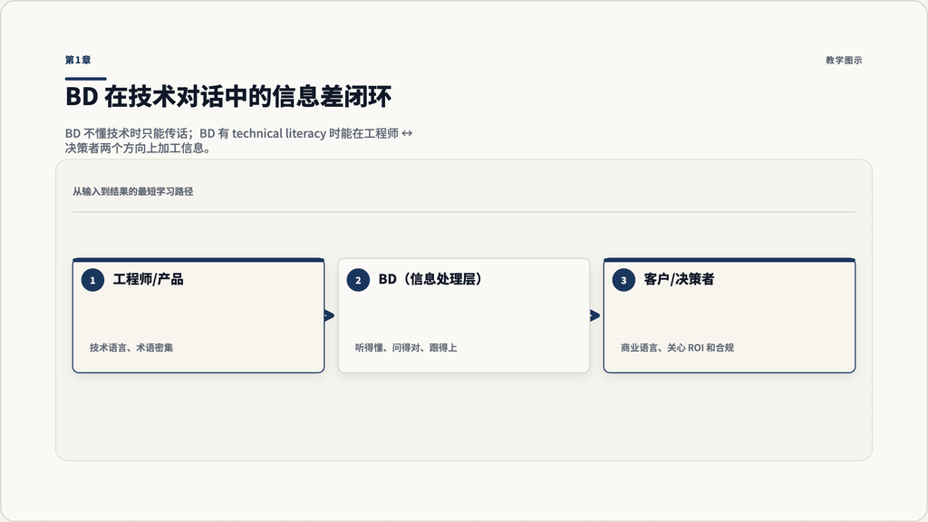

第1章：BD 在技术对话中的信息差闭环

图 1.1：一个不懂技术的 BD 在工程师 → 决策者的信息流里只能传话；一个有 literacy 的 BD 能在两个方向上加工信息。

### 1.5 BD 对话翻译

| 工程师/产品说 | BD 翻译给客户/老板 |
| --- | --- |
| 我们这车是 800V 平台 | 客户的 EV 能上你最快档位的桩，充电时长有竞争力 |
| 这个 SoC 是 Orin 254 TOPS | 这车的 ADAS 算力足够支撑 L2+ 高速场景，未来软件升级有余量 |
| 我们用 CTP 不是 CTC | 电池包还能后续维修，售后成本你别按”一体化”算 |
| 这电池是 LFP | 安全性好、寿命长，但低温续航会比 NMC 差 |
| 那个标准是 NACS | 北美未来主流接口，提前布局就是踩点 |

### 1.6 把术语归类的自查

下次开会前问自己一句：**如果工程师此刻讲一个我没听过的词，我能至少分辨它属于”电池/电机/充电/软件/制造”哪一类吗？**

如果还不行，往下读。

## 第2章 电池化学三大主流：LFP / NMC / NCA

### 2.1 为什么三个字母决定一切

EV 行业聊电池，开口第一个区分就是这三个字母组合。它们指的是电池正极材料的元素组成：

- **LFP** = 磷酸铁锂（Lithium Iron Phosphate）
- **NMC** = 镍钴锰（Nickel Manganese Cobalt）
- **NCA** = 镍钴铝（Nickel Cobalt Aluminum）

正极材料决定了电池的能量密度、循环寿命、热稳定性、成本——也决定了车企在用谁、为什么用。

### 2.2 三种化学的核心差异

| 维度 | LFP | NMC | NCA |
| --- | --- | --- | --- |
| 重量能量密度 | ~90-160 Wh/kg | ~150-250 Wh/kg | ~200-260 Wh/kg |
| 循环寿命 | 3000-6000+ 次 | 1000-2000 次 | 800-1500 次 |
| 热稳定性 | 最好（不易热失控） | 中 | 较差 |
| 成本 | 最低（无钴） | 中-高 | 高 |
| 主要使用方 | BYD、特斯拉入门版、储能 | 中国主流车厂高续航版、欧洲多数车厂 | 特斯拉部分车型、松下供货 |
| 低温表现 | 较差，需要更强热管理 | 较好 | 较好 |

> 注：以上 Wh/kg 数据为电芯级别（cell-level）公认区间，来自 DOE Vehicle Technologies Office 和 Argonne BatPaC 模型；具体到某一款电芯，OEM 会给出更精确的单值。

### 2.3 谁在用哪种，为什么

**BYD 全线 LFP**。从 2020 年发布”刀片电池”之后，BYD 把 LFP 作为主力，用长条形电芯设计弥补能量密度劣势，并用极强的热稳定性来卡品牌定位。

**CATL 双线并行**。CATL 既出 LFP，也出 NMC，给不同车厂不同价位段的产品。它在 2022 年宣布的”麒麟电池”是 CTP 3.0 架构，可以装 LFP 或 NMC。

**特斯拉混搭**。Model 3 标准续航版用 LFP（CATL 提供），长续航和性能版用 NCA 或 NMC（松下、LG 提供）。这是经典的”安全/低成本走 LFP，高性能走高镍”打法。

**欧洲车厂多用 NMC**。冬季低温续航更重要，NMC 在低温下相对友好，且欧洲对低成本路线的紧迫感弱于中国市场。

### 2.4 教学视觉

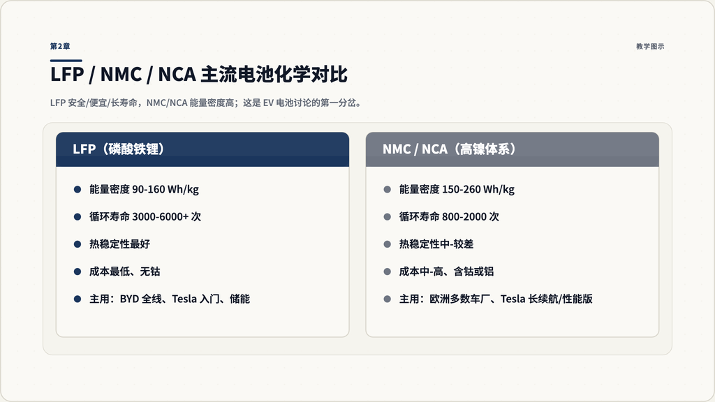

第2章：LFP / NMC / NCA 三种主流电池化学对比

图 2.1：三种化学的取舍是一组连锁——选了”安全 + 长寿命 + 低成本”就要让出”重量能量密度”。

### 2.5 常见陷阱

- 不要用单个 Wh/kg 数字比较两种化学。区间重叠很大，OEM 也会用电芯级或包级别的不同口径。
- 不要把”LFP = 便宜不高端”当成事实。特斯拉、宁德、比亚迪都在高端车型用 LFP，搭配 CTP 拉回能量密度劣势。
- 不要把”高镍 = 危险”说出口。NCA 的热稳定性较差是相对的，量产电池都有 BMS、热管理、机械防护多层兜底。

### 2.6 BD 对话翻译

| 工程师说 | BD 翻译 |
| --- | --- |
| 我们这款用 LFP | 安全好、寿命长、成本低，适合通勤+车队场景；低温续航要看车端热管理 |
| 我们高续航版上 NMC 811 | 镍 80%、锰 10%、钴 10%，能量密度高，但循环和热稳定要靠 BMS 和包结构 |
| 我们打算切换到无钴 | 成本控制和供应链风险都是动力；客户在 ESG 维度也会买账 |
| 这个电池密度做到 280Wh/kg | 这是电芯级别的高镍体系；做到包级别要再打七到八折 |

### 2.7 LFP + 800V 组合的反思

回到第1章的”800V 客户对话”。如果客户提到”我们 LFP 上 800V”，你会先想到什么？

提示：LFP 单电芯电压比 NMC 低（约 3.2V vs 3.6-3.7V），上 800V 需要更多串联或更高单电芯电压设计。这种细节你不用懂死，但听到”LFP + 800V”组合时，你应该知道这背后是电池厂下了功夫的设计。

## 第3章 化学路线图：固态、钠离子、半固态

### 3.1 不要把”明天就量产”当真

EV 行业最容易让 BD 翻车的就是化学路线图。媒体每隔几个月就会有”固态电池量产突破”的标题，结果三年过去还是在样品阶段。

记住三层时间感：

- **正在量产**：LFP、NMC、NCA（第2章讲过）
- **小规模量产或装车试验**：半固态、磷酸锰铁锂（LMFP）、钠离子（Na-ion）
- **公司公告目标，未大规模量产**：全固态（solid-state）

行业里所有”2027 年量产”、“2030 年规模化”的说法，**默认全部按 OEM 公告目标对待**，不要替对方背书时间。

### 3.2 三条主要研究路线

**全固态电池**。把传统液态电解液换成固态电解质，理论上能更高的能量密度、更安全、更宽的工作温度。难点是固态电解质和电极的界面接触、量产工艺、成本。Toyota、Samsung SDI、QuantumScape、Solid Power 都有公开路线图，量产装车规模仍在爬坡。

**钠离子电池**。用钠替代锂，资源更丰富、成本更低，能量密度低于 LFP 但可用于储能、A0 级小车、商用车。宁德时代 2021 年发布钠离子电池，部分车型试用。

**半固态/凝胶态**。介于液态和全固态之间，是当前最接近规模量产的”过渡形态”。中国部分新势力车型在试装。

**LMFP（磷酸锰铁锂）**。在 LFP 基础上加锰，能量密度提升约 15%，被视为 LFP 的下一代。

### 3.3 教学视觉

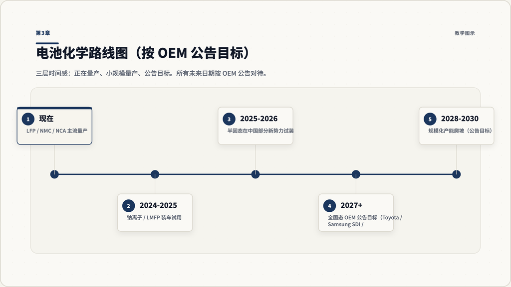

第3章：电池化学路线图（基于 OEM 公告目标）

图 3.1：从已量产的三种化学到 2030 之前的多条候选路线，时间标记一律按”OEM 公告”理解，不当作板上钉钉。

### 3.4 常见陷阱

- 不要把 “固态电池突破” 等同于 “明年装车量产”。 突破有多种含义：实验室样品、中试线、首装、规模化。中间还隔着多年。
- 不要把”能量密度 X Wh/kg”作为单点比较，要看是电芯级、包级、原型还是量产。
- 不要因为某家公司 PPT 上写了 2027 量产就在客户面前确认。 BD 要学会说”按厂商公告”。

### 3.5 BD 对话翻译

| 工程师说 | BD 翻译 |
| --- | --- |
| 我们 2027 量产全固态 | 厂商公告目标；客户做长期规划可以纳入，但短期采购决策按现有 LFP/NMC 来 |
| 这款车用半固态 | 介于液态和全固态之间，能量密度比 LFP 高，但量产规模有限，注意供货稳定性 |
| 我们布局了 LMFP | LFP 的下一代，能量密度有提升，主要针对中高端 LFP 路线的产品升级 |
| 钠离子主要打储能 | 车端目前主要在 A0 级小车试装；商用车和储能更先落地 |

### 3.6 给客户的固态押注回答骨架

如果客户在 2026 年问你”明年我们要不要押注固态电池路线”，正确的 BD 回答骨架是：

“按目前主要厂商公告，全固态规模量产至少要 2028 年以后；建议短期产品规划按 LFP/NMC 主流路线、长期产品做技术储备和供应链对接。需要的话我可以帮您整理一份截止当前的厂商路线图。”

不下时间结论，不替对方押注，但给出可执行的路径。

## 第4章 电芯形态：圆柱 vs 方形 vs 软包

### 4.1 4680、刀片、麒麟到底是什么

进入电池厂的会议，化学讲完之后第二个分岔就是”形态”。一个电芯长什么样，决定了它怎么装进电池包、怎么散热、怎么生产。

主流三种形态：

- **圆柱（cylindrical）**：像放大的干电池。常见型号 18650、21700、4680（特斯拉提出）。
- **方形（prismatic）**：长方体硬壳。BYD 刀片电池是一种特殊的”长条方形”，CATL 麒麟电池主要用方形。
- **软包（pouch）**：铝塑膜封装的扁平电芯。LG、SK On 主推。

### 4.2 三种形态的取舍

| 维度 | 圆柱 | 方形 | 软包 |
| --- | --- | --- | --- |
| 制造工艺成熟度 | 最成熟 | 成熟 | 较成熟 |
| 单体能量密度 | 中 | 中-高 | 高 |
| 散热表现 | 好（多接触面） | 中 | 中-差 |
| 安全/机械强度 | 高（金属壳） | 高（金属壳） | 较低（铝塑膜） |
| 适配 CTP 难度 | 较难（间隙多） | 容易 | 中 |
| 典型代表 | 特斯拉 4680、松下 21700 | BYD 刀片、CATL 麒麟 | LG / SK On |

### 4.3 三个明星产品到底是什么

**特斯拉 4680**。命名来自尺寸：46 毫米直径 × 80 毫米高。是 18650 和 21700 的放大版。特斯拉 2020 Battery Day 给出的目标是 5 倍能量、6 倍功率、便宜 56%。亮点是无极耳（tabless）设计、结构电池包（structural pack）、干法电极工艺。

注意：4680 量产爬坡比 PPT 慢得多，2024-2025 仍在持续扩产；具体年产量特斯拉不对外披露。

**BYD 刀片电池**。LFP 化学 + 超长方形电芯（长度近 1 米），直接以 CTP 形式排进电池包。BYD 强调它通过了针刺测试不冒烟不起火。亮点是用形态创新弥补 LFP 能量密度劣势，同时把整个包做得很扁。

**CATL 麒麟电池**。CTP 3.0 架构的代表，2022 年 6 月发布。CATL 宣称在同体积下比 4680 系统多 13% 能量。它是方形电芯 + 包内液冷板”夹心”结构。

### 4.4 教学视觉

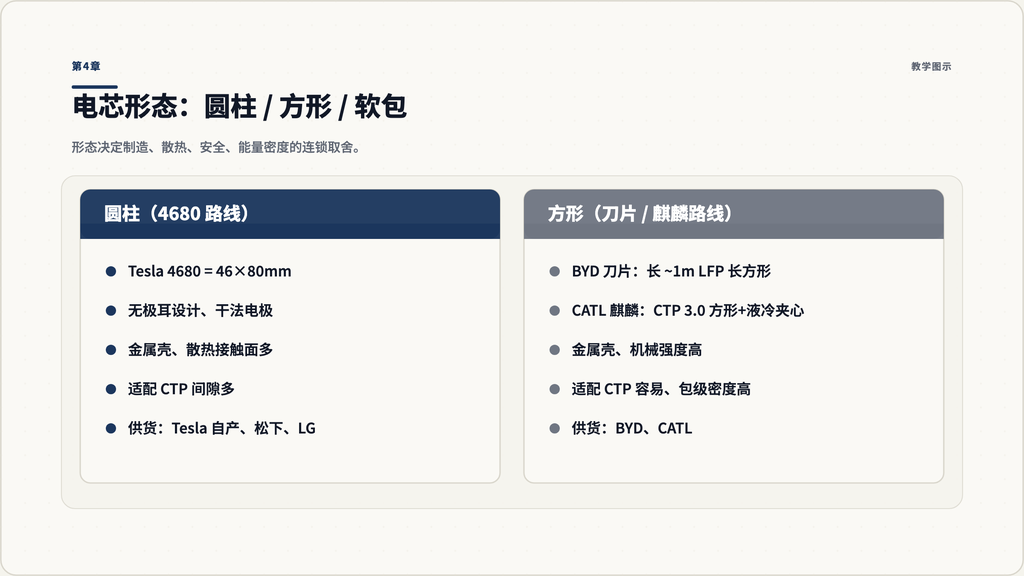

第4章：圆柱、方形、软包三种电芯形态对比

图 4.1：形态决定了制造、散热、安全和能量密度的连锁取舍。

### 4.5 常见陷阱

- 不要把”4680”当成一种化学。4680 是尺寸，化学可以是 NCA、NMC、LFP，对应不同应用。
- 不要相信单一来源的能量密度对比。CATL 说麒麟比 4680 强 13%，特斯拉不会同意。任何此类数字要标注立场。
- 不要把”软包不安全”说死。软包没有金属壳，但通过外部模组结构、热管理和 BMS 兜底，主流量产车型很多用软包。

### 4.6 BD 对话翻译

| 工程师说 | BD 翻译 |
| --- | --- |
| 我们这款上 4680 | 特斯拉路线，圆柱大电芯，能量+功率优势；产能爬坡阶段，关注供货稳定性 |
| BYD 刀片 + CTP | LFP 化学用形态创新拉回能量密度；安全口碑好，定价友好 |
| 我们用方形 + 液冷板夹心 | 类似 CATL 麒麟方案；包级能量密度好、热管理强 |
| 软包电芯，模组级保护 | 单体能量密度高，靠模组和热管理兜底；制造灵活，但机械强度依赖外壳 |

### 4.7 听到 4680 时的三个反问

下次有人说”我们用 4680”，第一时间反问自己三件事：

1. 它是什么化学（NCA / NMC / LFP）？
2. 是不是结构电池包（structural pack）？
3. 供货谁家（特斯拉自产、松下、LG、宁德、亿纬）？

这三个问号回答出来，你已经有 BD literacy 了。

## 第5章 电池包架构：cell → module → pack → CTP → CTC

### 5.1 为什么”少装一层”是个大故事

把电芯装到车上，传统做法是三层结构：

```
电芯（cell） → 模组（module） → 电池包（pack）
```

电芯先组成模组，模组再组成电池包，电池包装到车底盘上。

过去几年最大的架构创新就是**砍掉中间层**：

- **CTP（Cell to Pack）**：跳过模组，电芯直接进包。
- **CTC（Cell to Chassis）**：跳过模组和包，电芯直接装到底盘成为结构件。
- **CTB（Cell to Body）**：电芯参与车身结构（BYD 的命名）。

少一层意味着更轻、更紧凑、更多续航、更便宜——但也更难维修。

### 5.2 四代架构对比

| 维度 | 传统 cell→module→pack | CTP | CTC / CTB |
| --- | --- | --- | --- |
| 中间层级 | 三层 | 跳过模组 | 跳过模组和包 |
| 体积利用率 | 基线 | 提升约 15-30% | 进一步提升 |
| 重量利用率 | 基线 | 提升 | 进一步提升 |
| 维修便利 | 高（模组可替换） | 中 | 低（电芯坏整车修） |
| 代表产品 | 早期 Model S/X、传统车厂多数 | CATL 麒麟、BYD 刀片 | 特斯拉结构电池包、零跑、比亚迪 e 平台 |

> 注：CATL 公告麒麟相比同体积传统方案能量密度提升数据为厂商立场，建议交叉验证。

### 5.3 谁推动了这件事

**CATL 提 CTP**。2019 年起 CATL 提出 CTP 1.0，逐步演进到 2022 年的 3.0 麒麟。给的卖点是更高的体积利用率。

**BYD 用刀片 + CTP 做 CTB**。BYD 的刀片电池在 e 3.0 平台上是 CTB，电池既是储能件也是车身结构件。

**特斯拉用 4680 做结构电池包**。2020 Battery Day 提出 structural pack 概念，把电池包顶部作为底盘结构件，4680 之间用粘合剂填充承受机械载荷。这与 CTC 思路相同。

### 5.4 教学视觉

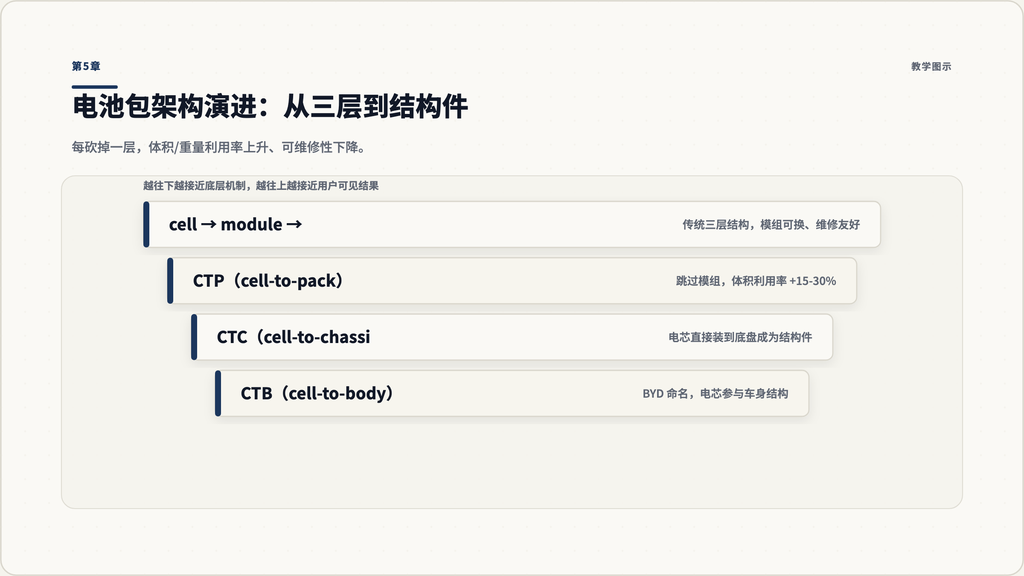

第5章：电池包架构演进 cell→module→pack→CTP→CTC

图 5.1：每砍掉一层，体积/重量利用率上升、可维修性下降。这是个明显的取舍曲线。

### 5.5 常见陷阱

- CTP 和 CTC 不是 “更好 vs 更差”，而是 “成本下降但维修变难”。 商务谈判时要替客户算总持有成本（TCO），不只是采购价。
- CTB 是 BYD 的命名，CTC 是特斯拉/学界更通用的命名，本质相同。
- 不是所有 CTP 都跳过了模组。 部分早期”CTP”方案保留了简化的模组结构。要看具体设计。

### 5.6 BD 对话翻译

| 工程师说 | BD 翻译 |
| --- | --- |
| 我们这款用 CTP | 体积利用率高，续航/包尺寸有优势；维修要看厂家政策 |
| 这是结构电池包 | 电池既是储能也是结构件；万一碰撞，维修成本要按”结构件”计 |
| 我们还是 module-based 方案 | 模组级可换，售后/二手价表现更友好 |
| CTB 路线 | BYD 命名，本质和 CTC 同向；适合一体化设计能力强的厂 |

### 5.7 同档便宜 5 万的成本来源拆解

客户问你”为什么这款车比同档便宜 5 万人民币但续航差不多？”

可能的答案之一：CTP/CTC 架构提升了体积利用率，让同样空间装更多电；同时整车厂砍掉了模组层级的物料和工艺成本。但你也要提醒客户：维修要看保修政策。

## 第6章 电机：永磁同步 vs 异步感应

### 6.1 两种电机为什么 BD 也要懂

EV 的电机讨论比电池少，但它直接影响：动力性能、能效、稀土供应、整车成本。BD 要至少能区分两种主流：

- **PMSM**（Permanent Magnet Synchronous Motor，永磁同步电机）：转子带永磁体（含稀土钕铁硼），效率高、功率密度高。
- **Induction Motor / Asynchronous Motor**（异步感应电机）：转子是导体笼，靠定子磁场感应电流产生转矩。不需要稀土，控制简单，但效率和功率密度略低。

### 6.2 两种电机的取舍

| 维度 | PMSM 永磁同步 | 异步感应 |
| --- | --- | --- |
| 效率（峰值） | 高（95%+） | 中（90%+） |
| 功率/重量比 | 高 | 中 |
| 高速区效率 | 中（弱磁需要控制） | 高（高速区更友好） |
| 成本 | 高（含稀土） | 低 |
| 稀土依赖 | 是 | 否 |
| 噪声/振动 | 较低 | 较高 |
| 主要使用方 | 多数中国新能源车、Tesla 后期主驱 | 特斯拉早期主驱（Model S/X 部分版本）、商用车 |

### 6.3 单/双/三电机布局是什么

整车的电机布局决定动力输出和驱动形式：

- **单电机**：通常前驱或后驱。入门版多见。
- **双电机**：前后各一，组成四驱（AWD）。大多数中高端 EV 的标配。
- **三电机/四电机**：高性能车（如 Lucid Air、Rivian R1T/R1S、特斯拉 Plaid、保时捷 Taycan Turbo S）用于极限性能或独立轮控。

布局决定的是性能上限、四驱能力、和成本结构。BD 在和客户谈采购时要分清：四驱不只是为了越野，还为了起步加速、操控稳定性。

### 6.4 800V 平台是什么，为什么是个卖点

传统 EV 多采用 400V 电池系统电压。把电压提升到 800V 有两层好处：

1. **充电更快**：同样功率下，电流减半，可以在不增加线缆粗度的前提下达到更高功率（P = U × I）。350kW 充电桩在 800V 平台上更容易跑满。
2. **电机效率更高**：高电压低电流意味着电机和逆变器的损耗降低，热管理压力减小。

代表车型：保时捷 Taycan（首款 800V 量产）、现代 IONIQ 5/6（E-GMP 平台）、起亚 EV6、Lucid Air、小鹏 G9/G6、比亚迪 e 平台 3.0 部分车型、极氪 001 FR 等。

代价：整车电气系统重新设计、SiC 功率器件成本更高、对充电桩端要求更高。

### 6.5 教学视觉

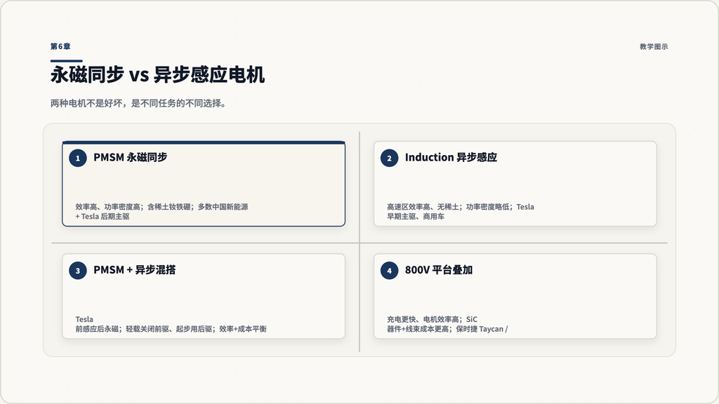

第6章：PMSM vs 异步感应电机对比矩阵

图 6.1：两种电机不是好坏关系，是不同任务的不同选择。

### 6.6 常见陷阱

- 不要把”特斯拉用感应电机”当成定论。早期 Model S/X 用感应主驱，后来切换到 PMSM 主驱 + 感应辅助。混搭策略。
- 800V 不只是个充电卖点。它对整车 BOM、热管理、SiC 器件、线束都有连锁影响。
- 三电机不等于”更快”。有时是给特定轮单独驱动，用于扭矩矢量控制。

### 6.7 BD 对话翻译

| 工程师说 | BD 翻译 |
| --- | --- |
| 主驱是 PMSM | 效率高、动力响应好；稀土供应是隐性变量 |
| 我们前驱用感应，后驱用永磁 | 巡航效率高（前感应在轻载关闭），起步用后永磁；效率+成本的平衡设计 |
| 我们是 800V 平台 | 充电更快、电机效率高；高压器件和线束成本更高 |
| 三电机布局 | 性能旗舰；扭矩矢量控制和加速能力是卖点 |

### 6.8 从”零百 2 秒”反推供应链

如果一款 EV 宣传”零百 2.x 秒”，你应该不只感叹快，而是想到：很可能是三电机 + 800V 平台 + 高功率电池放电能力的组合。这种组合背后是一条完整的供应链链路——你下次和这家车厂谈合作时，每一段链路都是潜在话题。

## 第7章 充电三大标准：NACS / CCS / GB/T

### 7.1 为什么北美和欧洲不一样

充电是 BD 工作中最容易被卷入的技术话题，因为它直接关系到客户体验、桩端建设、车端兼容性。BD 必须先理解三大标准的地理分布：

- **NACS**（North American Charging Standard）：原 Tesla 接口，2023 年 12 月被 SAE 标准化为 J3400。北美主流标准。
- **CCS**（Combined Charging System）：分 CCS1（北美旧标）和 CCS2（欧洲、澳洲）。
- **GB/T**：中国国家标准。

### 7.2 三大标准的核心差异

| 维度 | NACS / SAE J3400 | CCS1（北美旧） | CCS2（欧洲） | GB/T（中国） |
| --- | --- | --- | --- | --- |
| 主要地区 | 北美 | 北美（过渡中） | 欧洲、澳洲、东南亚 | 中国 |
| 接口物理形态 | 单接口 AC+DC | 上 AC（J1772）+ 下 DC | 上 AC（Type 2）+ 下 DC | AC 7 孔 + DC 9 孔 |
| 最高直流功率 | 各厂自定义（实测 250-500kW） | 350kW 级 | 350kW 级 | 250kW（V2G 演进中） |
| 协议层 | 与 CCS 兼容（PLC）演进中 | CCS 标准（PLC） | CCS 标准（PLC） | GB/T 27930（CAN） |
| 当前格局 | 2023-2024 主要 OEM 集体宣布采用 | 渐被 NACS 取代 | 稳定 | 稳定 |

### 7.3 NACS 转换是怎么发生的

2023 年 5 月，Ford 宣布北美车型从 2025 起切换到 NACS 接口，可以使用特斯拉超充网络。6 月 GM 跟进。之后 Rivian、Volvo、Mercedes、Nissan、Hyundai、Kia 等几乎所有主流 OEM 集体加入。

2023 年 12 月，SAE 把 NACS 正式标准化为 J3400，相当于”特斯拉的接口”变成”行业标准”。

对 BD 的含义：

- 桩端：CCS1 桩要加 NACS 接口或更换；新建桩默认双接口。
- 车端：2025-2026 是过渡期，新车多数原生 NACS，老车需要适配器。
- 协议层：物理接口换了，通信协议还在演进；不要把”接口对上”等同于”能充”。

### 7.4 AC 和 DC、Level 1/2/3 是什么

| 充电级别 | 电流类型 | 典型功率 | 接入位置 |
| --- | --- | --- | --- |
| Level 1 | AC | 1.4-1.9kW | 普通家用插座 |
| Level 2 | AC | 3.3-22kW | 家用墙盒、公共慢充 |
| Level 3 / DC Fast Charge | DC | 50-350kW+ | 公共快充站、超充 |

车端有 OBC（On-Board Charger）负责把 AC 转 DC 给电池。DC 快充绕过 OBC，桩直接给车电池供 DC。这就是为什么 DC 充电功率可以远高于 AC：不受车端 OBC 功率限制。

### 7.5 桩端功率 vs 车端接受功率

这是一个 BD 最容易答错的话题。

桩端标 350kW 不等于任何车都能充到 350kW。真实充电功率是 **min(桩端能力, 车端瞬时接受功率)**，而车端的接受功率受：

- 电池 SOC（充电曲线，越高 SOC 接受功率越低）
- 电池温度（过冷过热都会限流）
- 电压平台（400V 和 800V 上限不同）
- BMS 策略（厂商保守程度不同）

所以一款车的真实”快充体验”看的不是峰值，而是 **10%-80% 时间**和**充电曲线形状**。

### 7.6 教学视觉

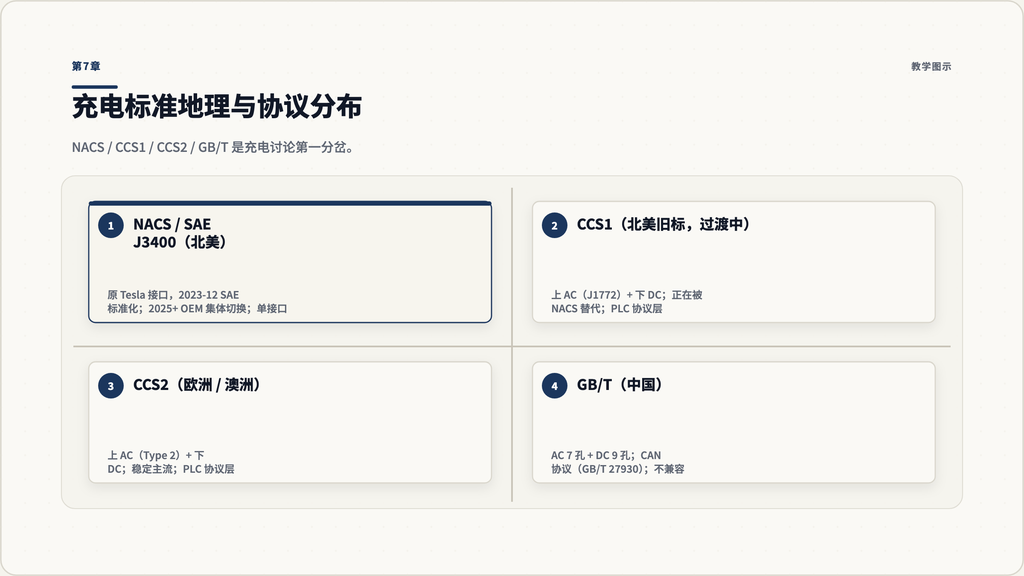

第7章：NACS / CCS1 / CCS2 / GB/T 充电标准对比

图 7.1：地理分布、物理接口、协议层都是独立维度，不要混着比。

### 7.7 常见陷阱

- 不要把 NACS 当成”Tesla 接口”。 2023 年 12 月之后它是 SAE J3400 标准，独立于特斯拉。
- 不要拿桩端最高功率给客户报真实充电时间。 必须看车的充电曲线。
- 不要把 CCS1 和 CCS2 混着说。 它们物理接口不同，不能互通。
- 不要忽略 GB/T。 即使你在北美做 BD，你接触的中国客户车厂技术团队都用 GB/T 思维。

### 7.8 BD 对话翻译

| 工程师/客户说 | BD 翻译 |
| --- | --- |
| 我们这桩是 350kW | 实际充电速度看车端电压平台和充电曲线，跑满需要 800V 车 |
| 我们 2026 切 NACS | 北美主流，先布局是对的；老车通过适配器临时过渡 |
| GB/T 不能直接接 NACS 桩 | 接口物理就不兼容；中国客户进北美要选支持 NACS 的车型 |
| 我们 10-80% 充电 18 分钟 | 这是有意义的实测数字，比”峰值 350kW”更能反映真实体验 |

### 7.9 加拿大铺 200 台超充桩的对话骨架

客户说”我们 2026 想在加拿大铺 200 台超充桩”。你的 BD 思路：

1. **接口**：默认 NACS + CCS1 双接口，未来 1-2 年是过渡期。
2. **功率**：单桩 350kW 是当前主流上限；液冷线缆是高功率持续输出的关键。
3. **场景**：高速场景需要快充，社区场景 Level 2 更合理。
4. **合规**：加拿大省级法规和电力公司接入要求要逐省查。

这就是一个有技术 literacy 的 BD 在 5 秒内能搭出来的对话框架。

## 第8章 ADAS / 自动驾驶分级

### 8.1 L2 和 L3 的法律含义不一样

“自动驾驶”是 BD 最容易踩雷的话题，因为公众语言、营销语言、法律语言、技术语言四套不重合。BD 要用 SAE J3016 的口径——这是行业唯一公认标准。

SAE J3016（2021 修订版）把驾驶自动化分为 6 个等级：

| 级别 | 谁负责动态驾驶任务 | 监控环境 | 应急响应 | 典型功能/例子 |
| --- | --- | --- | --- | --- |
| L0 | 人 | 人 | 人 | 仅警告，如盲点告警、AEB |
| L1 | 人 + 系统辅助 | 人 | 人 | 自适应巡航 ACC 或车道保持 LKA（二选一） |
| L2 | 人 + 系统辅助 | 人 | 人 | ACC + LKA 同时（Tesla AP、各种”高速领航”） |
| L3 | 系统（有限场景） | 系统（有限场景） | 人（需在 takeover 请求时接管） | Mercedes Drive Pilot、本田 Legend |
| L4 | 系统（限定场景） | 系统 | 系统（限定场景内） | Waymo Robotaxi（地理围栏内） |
| L5 | 系统（任何场景） | 系统 | 系统 | 暂无商用 |

**关键分界**：L2 是辅助，驾驶员必须随时接管；L3 是有限自动驾驶，系统在特定条件下负责，但要给驾驶员充足接管时间。L2 → L3 的法律责任和保险结构都会变。

### 8.2 纯视觉 vs 多传感器融合的争论

实现 L2+ 或 L3 需要传感器输入。两大路线：

**纯视觉路线（vision-only）**。代表是特斯拉。

- 公开事实：特斯拉 2021 年取消雷达，转向纯视觉（FSD Beta 时代）。HW3 → HW4（2023 推出）→ HW5（已公开提及）的硬件平台演进。
- 论点：人也是用眼睛开车，神经网络可以学到一切。
- 风险：弱光、雨雾、镜面反射等场景对纯视觉是硬挑战。

**多传感器融合路线**。代表是 Waymo、Mobileye、华为 ADS、小鹏 XNGP、蔚来 NAD 等。

- 配置：摄像头 + 毫米波雷达 + 激光雷达（lidar）+ 超声波。
- 论点：多模冗余对极端工况更鲁棒。
- 风险：BOM 成本更高，融合算法复杂。

注意：行业内有传闻特斯拉未来可能重新引入雷达或 lidar，但截至公开信息，这是传闻不是事实。BD 在客户面前不要替马斯克未来策略下结论。

### 8.3 教学视觉

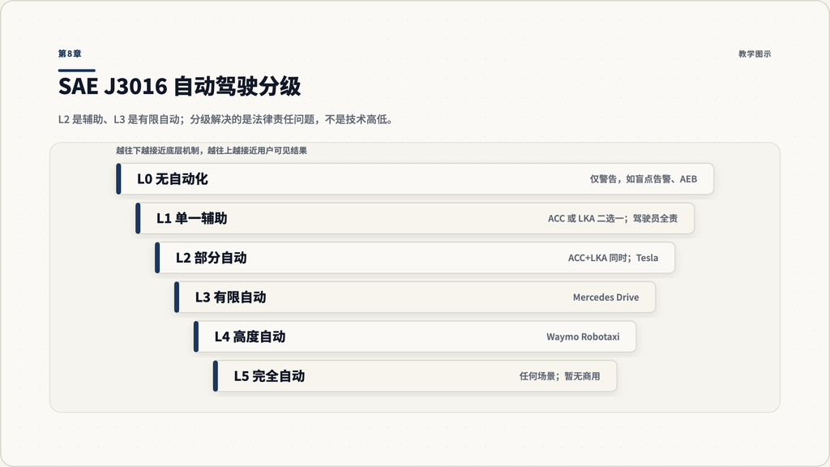

第8章：SAE L0-L5 自动驾驶分级与传感器路线

图 8.1：分级是责任问题，传感器是技术问题，两件事独立。

### 8.4 常见陷阱

- 不要把”自动驾驶”等同于 L4 或 L5。 量产车现在多数是 L2，少数是 L3，没有量产 L5。
- 不要把”摄像头数量”等同于”水平高”。 关键是算法、算力、训练数据规模。
- 不要承诺”我们这车是自动驾驶”。 BD 用词必须是”驾驶辅助”或者”高级辅助驾驶”。
- 不要在客户面前替特斯拉未来策略下结论。 HW5、lidar 重回这些是公开传闻或推测。

### 8.5 BD 对话翻译

| 工程师/产品说 | BD 翻译 |
| --- | --- |
| 我们这车 L2+ | 高速领航辅助；驾驶员必须随时接管，不是自动驾驶 |
| 我们走纯视觉路线 | 摄像头+神经网络方案，BOM 低、依赖训练数据；极端工况要看实际表现 |
| 我们配 lidar | 多模融合方案，BOM 高但极端工况冗余强 |
| 我们达到了 L3 | 有限场景自动驾驶；客户要看 ODD（设计运行域）和接管机制 |
| 我们这是 Orin 算力平台 | 254 TOPS，支撑 L2+ 高速领航有余量，未来 OTA 升级有空间 |

### 8.6 无人配送试点的合规回答骨架

客户问你：“这款车能不能算自动驾驶？我们想做无人配送试点。”

正确的 BD 回答骨架：

“按 SAE J3016 分级，这款车的辅助驾驶能力是 L2+ 或 L3（取决于车型版本和 ODD）。L4 / L5 无人化场景在公开道路上目前只有 Waymo 等少数运营商在特定地理围栏内试运营。无人配送的合规路径建议走专用车型 + 地理围栏 + 远程监控。”

不夸大、不下定论、给客户一个可执行方向。

## 第9章 软件定义汽车：E/E 架构与 SoC

### 9.1 为什么软件成了核心

过去十年，汽车从”机械+电子”变成”软件+电子+机械”。一辆 EV 的差异化越来越来自：

- 自动驾驶能力（取决于 SoC + 算法）
- 智能座舱（屏幕、语音、导航、应用生态）
- OTA（远程升级，把功能像 SaaS 一样持续推送）
- 车控逻辑（驾驶模式、能耗策略、个性化设置）

行业有个术语叫 **SDV（Software-Defined Vehicle）**。它代表的是整车的核心竞争力下移到软件层。

### 9.2 E/E 架构三代演进

**E/E** = Electrical/Electronic（电气电子）架构，指车上所有电子单元的拓扑组织。三代演进：

1. **第一代：分布式架构**。每个功能一个独立 ECU（电子控制单元），一辆传统车有 70-100 个 ECU。线束长且重，OTA 几乎不可能。
2. **第二代：域集中（domain-centralized）**。把多个 ECU 合并到几个域控制器（domain controller）：动力域、底盘域、车身域、智能座舱域、自动驾驶域。
3. **第三代：中央计算 + 区域（zonal）**。一个或两个中央高算力计算单元 + 几个分布在车身不同位置的”区域控制器”。线束按物理位置组织。

行业目前是第二代到第三代的过渡，部分新势力直接跳到第三代。

### 9.3 SoC 是什么

SoC（System-on-Chip，片上系统）是承载智能座舱或自动驾驶计算的”汽车大脑”。主流供应商：

- **Nvidia DRIVE Orin**：254 TOPS（算力单位）。广泛部署在 2023-2025 年的高端 EV（Volvo EX90、Nio ET7、小鹏 G9、理想 L9 等）。新一代 Thor 公告但量产爬坡中。
- **Qualcomm Snapdragon Ride** / **Ride Flex**：座舱+ADAS 一体化方案，2024 年起加速渗透。
- **华为 MDC**（Mobile Data Center）：MDC 810 / 610 等型号，给问界、阿维塔、智界、极狐等车型供货。受美方制裁影响，供应链有不确定性。
- **地平线 征程**：J5、J6 等，主打中国本土 OEM。
- **Mobileye EyeQ**：EyeQ5 / EyeQ6 等，给宝马、福特、大众等供货，传统稳定路线。

注意：TOPS（Tera Operations Per Second）是算力指标，不是性能指标。**算力 ≠ 实际 ADAS 表现**，因为还看算法、数据、传感器。

### 9.4 OTA 能升级什么不能升级什么

OTA（Over-The-Air）允许车厂远程推送软件更新。常见可升级项：

- 驾驶辅助功能（如新增高速领航、城区领航）
- 座舱 UI、语音助手、应用
- 充电策略、能耗管理
- 车控参数（加速曲线、悬挂阻尼）
- BMS 策略

**不能 OTA 升级的**：

- 物理硬件（电机、电池、传感器）
- SoC 算力上限
- 充电接口
- 机械结构件

经常出现的”OTA 升级 ADAS”是软件优化在现有硬件上的提升，**不是把 HW3 升到 HW4**。BD 在客户面前要把这个边界讲清。

### 9.5 教学视觉

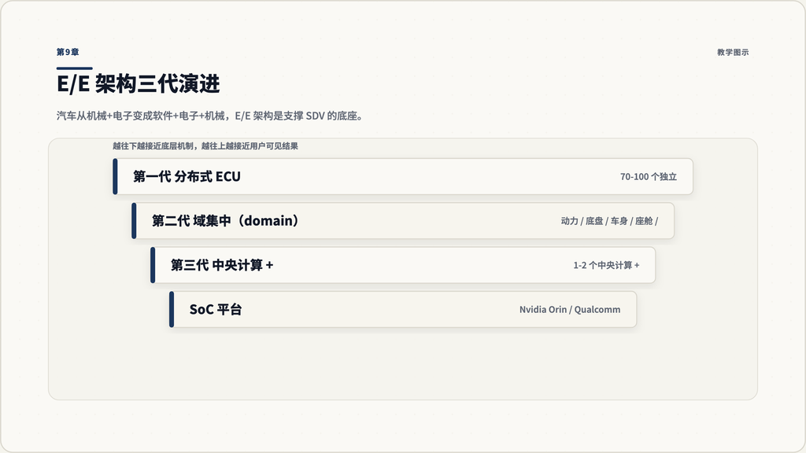

第9章：E/E 架构三代演进与典型 SoC 平台

图 9.1：从 70+ 个 ECU 的分布式架构，到中央计算 + 区域控制的最新一代。线束长度、算力集中度、OTA 能力都连锁变化。

### 9.6 常见陷阱

- 不要把 SoC TOPS 当性能。 一辆车 ADAS 好不好，看算法+数据+传感器+SoC 四件套。
- 不要把 OTA 当万能。 物理硬件 OTA 不动。
- 不要把”分布式架构”说成落后。 部分传统 OEM 还在用，原因是稳定性、供应链、责任分配。
- 不要混用”SDV”和”L4”。 SDV 指软件可持续更新，不代表自动驾驶水平。

### 9.7 BD 对话翻译

| 工程师/产品说 | BD 翻译 |
| --- | --- |
| 我们走 SDV 架构 | 整车软件可持续 OTA 更新，差异化在软件层；客户得到的是会”长大”的车 |
| 我们 SoC 用 Orin | 高算力平台，ADAS 和座舱有未来升级空间 |
| 我们域控制器三个 | 中间一代架构，比分布式好，但还不是全中央计算 |
| 这是中央计算 + 区域架构 | 第三代 E/E，线束更短、算力更集中、OTA 能力最强 |
| 这功能要 OTA 升级 | 注意：只升软件不升硬件；客户要看清晰的升级路线图 |

### 9.8 为什么这家车厂能持续推新功能

客户问你：“为什么这家车厂能持续推新功能？”

答案骨架：他们走的是 SDV + 中央计算 + 强 OTA 能力的组合。这背后是 E/E 架构投资 + 算法团队规模 + 数据回传机制。客户买车其实是”加入一个软件平台”，未来 5 年的体验取决于这家厂的软件路线图。

## 第10章 BMS 与热管理

### 10.1 为什么 BMS 决定了电池”活多久”

电池本身只是化学储能。让它在车上工作十年、跑几十万公里、不起火、不掉电太快——靠的是 **BMS（Battery Management System，电池管理系统）**。

BMS 干三件事：

1. **监测**：每个电芯的电压、电流、温度、SOC（剩余电量）、SOH（健康度）。
2. **均衡**：电芯之间能量不均时，主动或被动调整。
3. **保护**：过充、过放、过温、短路时切断或限流。

BMS 还决定了：充电曲线、回收能量策略、电池寿命。一个好的 BMS 算法可以让同样的电芯多用 30%+ 寿命。

### 10.2 热失控为什么是核心安全话题

锂离子电池在异常情况下（机械损伤、过充、短路、过温）会进入 **thermal runaway 热失控**：电芯内部反应放热，温度急剧上升，能引燃相邻电芯，造成”传播式”火灾。

EV 行业的安全设计分三层：

1. **电芯级**：化学体系（LFP 比 NCA 稳定）、隔膜、防爆阀。
2. **模组/包级**：防火隔板、消防排气通道、阻燃材料。
3. **整车级**：碰撞溃缩区、断电策略、消防泄压通道。

中国 GB 38031 标准要求电池包在单电芯热失控后 5 分钟内不蔓延到整包，这是一条公开的工程目标。北美 / 欧洲有等效要求，具体条款不同。

### 10.3 三种主流冷却方式

| 冷却方式 | 原理 | 优点 | 缺点 | 代表 |
| --- | --- | --- | --- | --- |
| 风冷 | 空气流过电池包 | 简单、低成本 | 散热能力弱 | 早期日产 Leaf |
| 液冷（间接） | 冷却液经板状或管状散热器 | 散热好、可加热 | 复杂、需密封 | 大多数现代 EV |
| 直冷（制冷剂） | 制冷剂直接进电池包 | 散热效率最高 | 工程难度高 | 部分最新车型 |

热管理不只是”散热”。冬天低温时，电池需要被加热到工作温度才能放出额定功率——这就是为什么冬天电动车续航打折。热泵空调（heat pump）现在是高端 EV 的标配，它能把车外热量”泵”进来，比电阻加热效率高数倍。

### 10.4 教学视觉

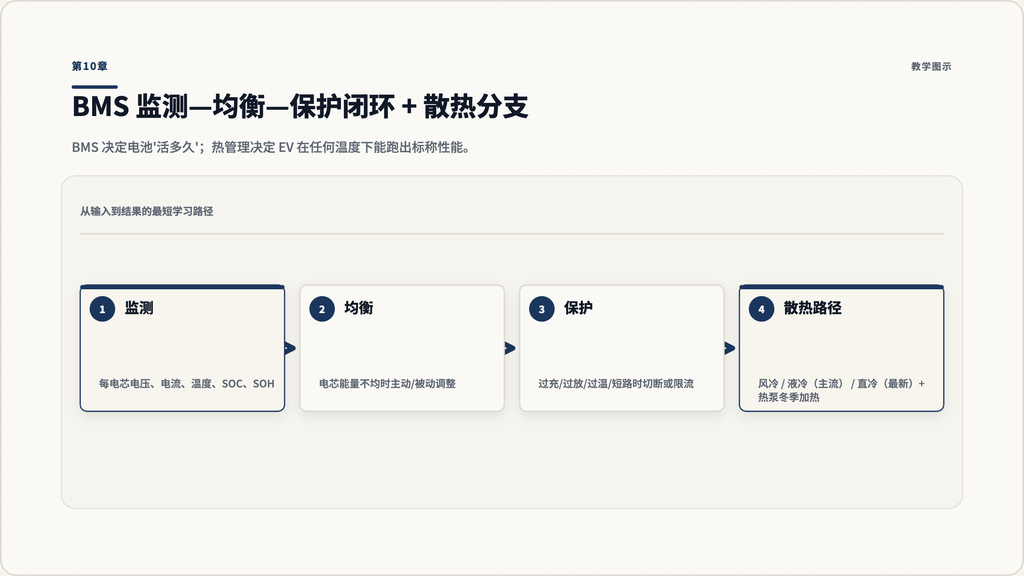

第10章：BMS 监测—均衡—保护闭环 + 三种冷却方式

图 10.1：BMS 是个永不停的闭环；散热是 EV 在所有温度区间能跑出标称性能的前提。

### 10.5 常见陷阱

- 不要把 BMS 说成”芯片”。 它是一套软件 + 硬件 + 算法的系统。
- 不要承诺”绝对不起火”。 任何锂电都有概率风险，主流车型用多层防护把概率降到极低，但不是零。
- 不要混淆 SOC 和 SOH。 SOC 是当前剩余电量（State of Charge），SOH 是电池健康度（State of Health）。
- 不要在冬天续航话题上一概而论。 取决于电池化学（LFP 受影响更大）、热泵、预热策略。

### 10.6 BD 对话翻译

| 工程师/产品说 | BD 翻译 |
| --- | --- |
| 我们 BMS 算法是自研的 | 整车厂控制了电池寿命和充电曲线，不依赖电池厂打包方案 |
| 我们用液冷板 | 主流散热方案，快充和长时间高功率输出有保障 |
| 我们装了热泵 | 冬季能耗友好；冷区市场是个卖点 |
| 我们过了 GB 38031 / 等效标准 | 单电芯热失控不会快速蔓延，保险公司也能算出风险 |
| SOH 80% 保 8 年/16 万公里 | 这是标准的电池保修口径，告知客户残值定价 |

### 10.7 冬天续航缩水多少的回答框架

客户问你：“这车冬天续航缩水多少？”

答案骨架：取决于化学（LFP 影响更大）、是否有热泵、用户是否使用预热、外部温度。给一个范围（如 LFP 在 -10°C 可能掉 25-40%，搭配热泵可降低损失），并建议客户看实测数据而不是 OEM 标称。

## 第11章 制造创新：一体压铸、结构电池、4680 量产

### 11.1 Tesla 的 9000 吨级压铸机要省什么

特斯拉在 Fremont 和 Giga Berlin / Texas 装了”giga press”——单台 9000 吨级压铸机，把整车下车体后段或前舱用一次压铸成型，取代原来 70+ 个冲压焊接件。

省的是：

- 冲压 + 焊接的工艺步骤
- 大量焊接夹具和工装
- 部分钢制零件的轻量化（铝合金压铸）
- 装配线的工位数

代价是：

- 单台压铸机投入巨大（数千万美元）
- 一次压铸件碰撞维修难（不能像传统钣金那样切割修复）
- 良率和工艺验证周期长

跟进者：小鹏、蔚来、比亚迪、特别是中国新势力都在快速跟进，部分使用 6000-12000 吨级压铸机。

### 11.2 结构电池包是什么

第5章讲过 CTC / 结构电池包的概念。这里讲它作为”制造创新”的另一面：

传统电池包是独立结构，装到车底盘上。结构电池包把电池包顶部直接作为底盘地板，电芯之间用粘合剂填充承担机械载荷。

好处：

- 减少底盘地板这一层结构件
- 整车重心更低
- 整体刚度提升
- 减少零部件数量

代价：

- 电池有问题要整体处理
- 维修门槛高
- 工艺要求极高

### 11.3 4680 量产为什么慢

特斯拉 2020 Battery Day 给出的 4680 路线包括三个一起拉的创新：

1. **形态**：4680 大圆柱
2. **无极耳设计**：tabless，减小内阻和热点
3. **干法电极**：取代传统湿法涂布，能耗低 10x、占地小 10x

三件事一起做意味着三个学习曲线并行。任何一个出问题都拖整体。2022-2025 持续在爬坡，特斯拉自己造、松下也造、LG 跟进。具体年产量特斯拉不对外披露，行业普遍判断是产能持续提升但仍未达到 PPT 上的理论目标。

### 11.4 中国新势力的造车路径差异

**华为** 走”不造车，提供解决方案”路线：HI（Huawei Inside）和”鸿蒙智行”两种合作模式，给问界、智界、阿维塔、享界、尊界供货 SoC、座舱、ADAS、三电系统。

**小米** 走”自建工厂 + 自主品牌”路线：SU7、YU7 等，2024 起量产，依靠手机制造和供应链整合能力。

**百度极越** 走”和吉利合资”路线（注：截至 2025 公开信息，极越业务调整频繁，BD 在客户面前讲到时按”目前公开状态”表述）。

这些不同路径决定了 BD 和它们打交道时的合作姿态完全不同：纯方案商可以一对多，自建工厂的需要按整车厂走流程。

### 11.5 教学视觉

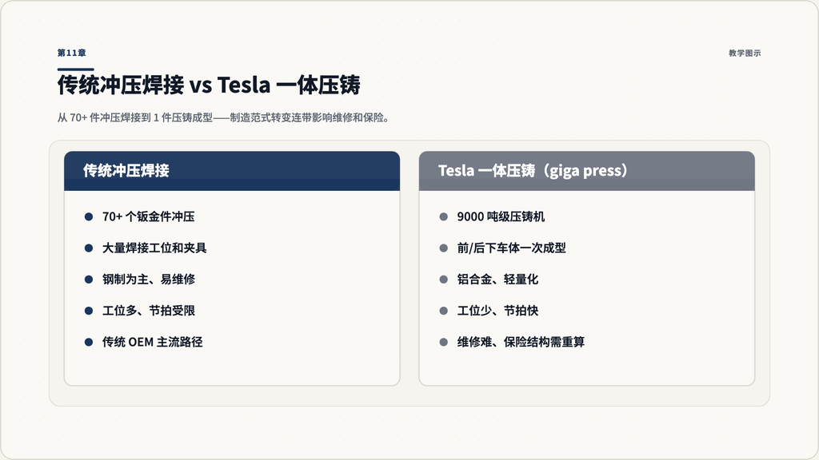

第11章：传统冲压焊接 vs Tesla 一体压铸

图 11.1：从 70+ 件冲压焊接，到 1 件压铸成型。这是制造范式的转变，连带影响维修成本和保险结构。

### 11.6 常见陷阱

- 不要把”一体压铸”等同于”质量更好”。它优化的是制造效率和重量，但维修成本是连锁代价。
- 4680 量产数据不公开发布。 别报具体数字，用”持续爬坡”或”产能爬升中”。
- 不要把华为不造车与”华为车业务弱”等同。 它是供给侧的关键玩家，BD 必须能区分多种合作模式。

### 11.7 BD 对话翻译

| 工程师/产品说 | BD 翻译 |
| --- | --- |
| 我们用 giga press 一体压铸 | 制造效率高、轻量化、装配快；维修成本是客户要算的另一面 |
| 这是结构电池包 | 整车刚度好、能耗低；售后处理流程要看厂方说明 |
| 我们 4680 自产 | 长线降本路径，但产能爬升中；不要把它当成已经规模化 |
| 华为 HI 模式 / 鸿蒙智行 | 两种合作模式：HI 是供应商，鸿蒙智行是渠道+品牌+方案三合一 |

### 11.8 同档便宜 10-20% 的来源组合

客户问你：“为什么这车 OEM 能比同档便宜 10%-20%？”

可能的答案组合：CTP/CTC 架构 + 一体压铸 + 自研 BMS 与 SoC + 垂直整合供应链 + 工厂自动化。BD 应该能在 30 秒内说出至少 3 条来源。

## 第12章 回收与二次寿命

### 12.1 退役电池的去向

EV 电池退役不是”扔掉”。当电池容量降到约 70-80% 时，对车端来说续航和功率都下降到不能接受的程度，但电池本身还能用——只是不能再用于”高动力需求场景”。

退役电池有两条主流去向：

1. **梯次利用（second-life）**：把还能用的电芯/模组重组，用于储能、备电、低速车、慢充桩等。
2. **拆解回收（material recovery）**：把电池物理拆解、化学处理，回收锂、钴、镍、铜、铝等关键矿物，重新进入电池供应链。

### 12.2 三种回收工艺

| 工艺 | 原理 | 优点 | 缺点 | 行业现状 |
| --- | --- | --- | --- | --- |
| 火法（pyrometallurgy） | 高温熔炼 | 工艺成熟、设备简单 | 能耗高、锂回收率低、有废气 | 部分欧洲老牌冶炼厂 |
| 湿法（hydrometallurgy） | 化学溶解 → 萃取 | 锂回收率高、副产物可控 | 化学品消耗、流程长 | 主流，CATL、华友、Redwood、Li-Cycle 等 |
| 直接回收（direct） | 不打散材料结构，直接修复电极 | 理论上能耗低、循环效率最高 | 主要在研发阶段 | 各国实验室 |

### 12.3 北美回收产能现状

主要玩家：

- **Redwood Materials**（内华达，JB Straubel 创立）：闭环战略，与福特、大众、丰田、特斯拉等都有合作。目标是建立北美闭环。
- **Li-Cycle**（多伦多 / 北美）：spoke-and-hub 模式，spoke 端收集和预处理，hub 端化学处理。2024 起经历了资本结构调整，BD 在客户面前讲到时按”持续运营，但具体产能要看最新公开数据”。
- **Ascend Elements**、**ABTC** 等其他玩家。

行业整体：北美回收产能在快速建设，但当前退役电池量还在累积期。真正的大规模退役潮预计在 2030 年后。

### 12.4 教学视觉

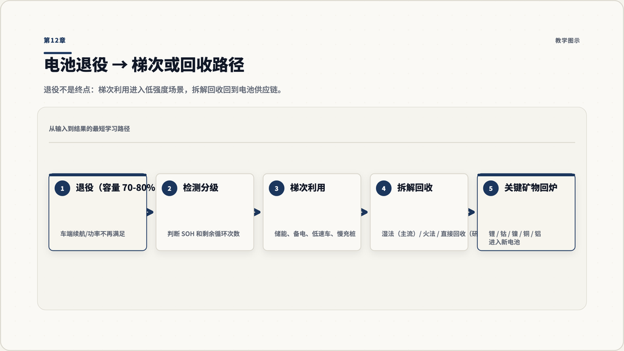

第12章：电池退役与回收路径

图 12.1：退役 → 检测 → 梯次利用或拆解 → 关键矿物回到电池供应链。这是一个真正的闭环路径，不是”扔掉”。

### 12.5 常见陷阱

- 不要把”梯次利用”和”拆解回收”混着说。前者是把电池用作其他低强度场景，后者是把电池打散回收原材料。
- 不要给 Redwood / Li-Cycle 报具体年处理吨位。 公开数据更新快，按截止时间表述。
- 不要把”闭环回收”当成现状。 它是个产业方向，目前北美产能爬坡中。
- 别忽略法规：欧盟电池法规（EU Battery Regulation）要求 2027 起新电池必须含一定比例的回收材料；北美也有类似立法讨论。

### 12.6 BD 对话翻译

| 工程师/产品说 | BD 翻译 |
| --- | --- |
| 我们和 Redwood 合作回收 | 闭环战略；客户的 ESG 报告可以纳入 |
| 这电池能进梯次 | 二手价值会比”直接报废”高，残值定价可以乐观一点 |
| 我们湿法回收线 | 主流工艺，锂/钴/镍回收率高，符合未来法规对回收材料比例的要求 |
| 北美回收产能不够 | 短期靠出口或自建，长期看 Redwood、Li-Cycle 等本土玩家爬坡 |

### 12.7 八年后退役电池的处理路径

客户问你：“我们 8 年后退役的电池怎么处理？”

答案骨架：两条路径——梯次利用进入储能/慢充/备电；直接拆解回收锂钴镍。具体选哪条看电池退役时的健康状态。当前北美回收产能在建设期，建议在采购合同里就锁定厂家或第三方的回收/再利用合作路径。

## 第13章 EV 规格表怎么读

### 13.1 BD 应该先看哪 6 个数字

EV spec sheet 有上百项。BD 在 5 分钟内能看明白的核心是 6 个数字：

| 指标 | 单位 | 看什么 |
| --- | --- | --- |
| 电池容量 | kWh | 整体能量储备，决定续航上限 |
| 峰值/持续功率 | kW | 加速能力和持续输出，影响动力体验 |
| 0-100 km/h | 秒 | 加速性能直观对比 |
| 续航 | km / mile（WLTP / EPA / CLTC） | 关键：必须注明哪套口径 |
| DC 快充功率（峰值 + 10-80%时间） | kW + 分钟 | 真实补能体验 |
| 平台电压 | V（400 vs 800） | 充电速度、电机效率、整车架构 |

### 13.2 三套续航口径的差异

| 标准 | 地区 | 典型乐观度 |
| --- | --- | --- |
| WLTP（Worldwide Harmonised Light Vehicles Test Procedure） | 欧洲 | 中 |
| EPA（U.S. Environmental Protection Agency） | 北美 | 最保守（最贴近真实） |
| CLTC（China Light-Duty Vehicle Test Cycle） | 中国 | 最乐观 |
| NEDC（New European Driving Cycle，已淘汰） | 早期欧洲 | 最乐观（已退出） |

经验法则：CLTC 续航 × 0.7 ≈ EPA 续航，是个粗略转换。不要用 CLTC 数字在北美客户面前讲续航。

### 13.3 一份典型 spec sheet 的 BD 解读

设想你拿到一份 2026 款国产 EV 的规格表，节选：

| 指标 | 数值 | BD 解读 |
| --- | --- | --- |
| 电池容量 | 100 kWh | 中大型 EV，主流续航段 |
| 化学 | NMC | 高能量密度，冬季表现相对友好 |
| 平台电压 | 800V | 充电快、电机效率高 |
| 峰值功率 | 480 kW（双电机） | 高性能区间，0-100 在 3.x 秒 |
| 0-100 km/h | 3.8 秒 | 性能旗舰 |
| CLTC 续航 | 700 km | 真实续航估计 EPA 约 500 km |
| DC 充电峰值 | 350 kW | 跑满需要 800V 桩 |
| 10-80% 充电时间 | 18 分钟 | 真实快充体验良好 |
| ADAS 平台 | Nvidia Orin × 2（508 TOPS） | L2+ 城市领航能力 + OTA 升级空间 |
| 整车架构 | E/E 中央计算 + 区域 | 第三代架构，OTA 能力最强 |

### 13.4 教学视觉

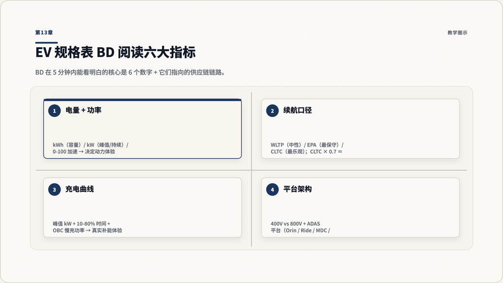

第13章：EV 规格表 BD 阅读六大指标

图 13.1：6 个数字是 BD 在 5 分钟内能读出整车价值定位的关键。每个数字背后都连着前面 12 章讲的某一个主题。

### 13.5 常见陷阱

- 不要把 CLTC 数字直接拿到北美客户面前。 要么换算到 EPA，要么标明口径。
- 不要单看峰值充电功率。 要看 10-80% 实测时间和充电曲线。
- 不要忽略平台电压。 同样 350kW 桩在 400V 和 800V 上的真实表现不一样。
- 不要忽略 OBC 功率。 家用 Level 2 慢充体验取决于车端 OBC 上限（多为 11kW 或 22kW）。

### 13.6 BD 对话翻译

[output not shown]

### 13.7 5 分钟 spec 速读练习

拿到一份新车 spec sheet，在 5 分钟内用 6 个数字写一段 100 字的 BD 一句话总结。**练习这个动作**，等你能熟练做到，下一次开会就能现场做。

## 第14章 BD 对话翻译总表

### 14.1 这一章为什么独立

前面 13 章每章都有一节”BD 对话翻译”。这一章把它们集中起来作为可随时查阅的总表，并补充 8 个高频场景。

### 14.2 八个高频场景

**场景 1：客户问”你们的桩能不能给我们车快充？“**

不要只回功率。回三问：你们车是 400V 还是 800V？你们用的充电接口是 NACS 还是 CCS？你们的 BMS 在 80% 以上 SOC 时的限流策略？

**场景 2：客户说”我们 2027 年想用固态电池路线”**

按 OEM 公告目标记录，不要替对方背书时间。建议短期方案锁定 LFP/NMC，长期方案做技术储备和供应链跟踪。

**场景 3：工程师抛了一堆充电故障错误码**

先判断属于哪一层：物理接口、通信协议、车端 BMS、电池温度、桩端硬件。给客户一个临时解释方向，然后说”我让工程团队详细回复”。

**场景 4：客户要做车队（fleet）采购，比较两款车**

至少对比这 8 项：电量、化学、平台电压、快充时间、ADAS 平台、E/E 架构、OTA 能力、回收策略。不要只比”续航和价格”。

**场景 5：客户问”OTA 能不能升级 ADAS 到 L3？“**

清楚说边界：OTA 升级软件不升级硬件。如果硬件平台（SoC、传感器套件）支持 L3，可以通过 OTA 解锁更多功能；如果硬件平台不支持，OTA 升不上去。

**场景 6：客户问”这车冬天续航缩水多少？“**

不要给单一数字。回答应包括：电池化学（LFP 受影响更大）、是否有热泵、用户预热习惯、外部温度区间。

**场景 7：客户问”为什么这车比同档便宜很多？“**

可能的答案组合：架构（CTP/CTC）、化学（LFP 替代 NMC）、制造（一体压铸）、垂直整合（自研 BMS / 三电）、销售模式（直营）。

**场景 8：客户问”这车 8 年后残值怎么算？“**

涉及 SOH 保修、电池退役处理、梯次利用是否进入合同、整车保修条款。BD 应该能给出残值定价的关键变量框架。

### 14.3 总表索引

| 主题 | 关键术语 | 章节 |
| --- | --- | --- |
| 电池化学 | LFP / NMC / NCA | 第2章 |
| 化学路线图 | 固态、钠离子、半固态、LMFP | 第3章 |
| 电芯形态 | 4680 / 刀片 / 麒麟 | 第4章 |
| 电池包架构 | cell→module→pack / CTP / CTC / CTB | 第5章 |
| 电机 | PMSM / 异步感应 / 800V | 第6章 |
| 充电标准 | NACS / CCS / GB/T / Level 1/2/3 | 第7章 |
| 自动驾驶分级 | SAE L0-L5 / 纯视觉 / lidar | 第8章 |
| 软件定义汽车 | SDV / E/E 架构 / Orin / OTA | 第9章 |
| BMS 与热管理 | BMS / SOC / SOH / 热泵 / 热失控 | 第10章 |
| 制造创新 | giga press / 结构电池 / 4680 量产 | 第11章 |
| 回收 | 梯次利用 / 湿法 / 火法 / Redwood | 第12章 |
| 规格表 | kWh / kW / EPA / CLTC / 充电曲线 | 第13章 |

### 14.4 教学视觉

[figure not shown]

### 14.5 最后的练习

拿出最近一次和 EV 工程师/产品/合作方的真实对话记录（或一段你模拟的对话）。用本手册的 BD 翻译思路重写一遍。重点不是术语正确，是**对话的话权**——你是被工程师牵着走，还是能把对话推到你想去的位置。

### 14.6 自检表

| 能力 | 我能做到吗 |
| --- | --- |
| 听到 LFP / NMC / NCA 三个词能马上分辨化学路线 |  |
| 看到 4680 / 刀片 / 麒麟能说出哪种形态 + 谁在用 |  |
| 解释 CTP 和 CTC 区别，并讲出维修成本含义 |  |
| 区分 NACS / CCS / GB/T，知道地理分布 |  |
| 看到 800V 平台能立刻关联充电速度和电机效率 |  |
| 用 SAE J3016 解释 L2 vs L3 |  |
| 说出 Nvidia Orin、Qualcomm Ride、华为 MDC、地平线征程的定位 |  |
| 解释 BMS 三大职能和热管理三种方式 |  |
| 说出 giga press 一体压铸和结构电池包的取舍 |  |
| 知道 Redwood、Li-Cycle 等北美回收玩家定位 |  |
| 拿到 spec sheet 能在 5 分钟内说出 6 个核心数字 |  |
| 八个 BD 对话场景能在客户面前快速展开 |  |

如果你能勾上 10 项以上，你已经具备了 EV BD 的技术 literacy。接下来要做的是**反复跑实战对话**，让这些知识从”我知道”变成”我条件反射”。

## 写在最后

技术 literacy 不是终点，是入场券。

读完这本手册，你能听懂大多数 EV 行业的技术对话。但真正让你成为 EV BD 高手的，是后面三件事：

1. **持续跟踪产业**。化学路线、SoC 算力、充电标准、回收法规都在快速演进。每周给自己 30 分钟看 InsideEVs、Electrek、CnEVPost 等。
2. **建立你的工程师人脉**。BD 的技术深度有边界，工程师朋友是你的”延伸算力”。请他们吃饭，问得多。
3. **在每次对话后做复盘**。这次客户问的什么我没接住？这次我把哪个术语用对了？记下来，下次更顺。

这本手册的价值不在它讲了什么，在你下一次进会议时是不是真的多说了一句关键的话。

祝你下一个 BD 项目跑得快、跑得稳。

## 延伸阅读

- DOE Vehicle Technologies Office — Batteries：energy.gov/eere/vehicles/batteries
- Argonne National Lab BatPaC 模型：anl.gov/cse/batpac-model-software
- IEA Global EV Outlook（年度报告）：iea.org/reports/global-ev-outlook-2024
- SAE J3016 驾驶自动化分级标准：sae.org/standards/content/j3016_202104
- SAE J3400 NACS 标准：sae.org/standards/content/j3400
- Battery University：batteryuniversity.com
- InsideEVs / Electrek / CnEVPost：行业新闻持续跟踪
- Nature Energy / Joule：peer-reviewed 电池研究综述